# Paired Data

Sometimes we encounter data sets that are pairs of values. For example, we may collect data on homes sold in Medina, WA. Rather than simply collecting a single value for each one, we may collect their selling price along with the square footage. In such a scenario, we would like to see if the values have any relationship between them.

```python
import numpy as np
import matplotlib.pyplot as plt
import pandas as pd
```

```python
data = pd.read_csv('home_data.csv')
data.info()
```

```
<class 'pandas.core.frame.DataFrame'>
RangeIndex: 21613 entries, 0 to 21612
Data columns (total 21 columns):
 #   Column         Non-Null Count  Dtype
---  ------         --------------  -----
 0   id             21613 non-null  int64
 1   date           21613 non-null  object
 2   price          21613 non-null  float64
 3   bedrooms       21613 non-null  int64
 4   bathrooms      21613 non-null  float64
 5   sqft_living    21613 non-null  int64
 6   sqft_lot       21613 non-null  float64
 7   floors         21613 non-null  float64
 8   waterfront     21613 non-null  int64
 9   view           21613 non-null  int64
 10  condition      21613 non-null  int64
 11  grade          21613 non-null  int64
 12  sqft_above     21613 non-null  int64
 13  sqft_basement  21613 non-null  int64
 14  yr_built       21613 non-null  int64
 15  yr_renovated   21613 non-null  int64
 16  zipcode        21613 non-null  int64
 17  lat            21613 non-null  float64
 18  long           21613 non-null  float64
 19  sqft_living15  21613 non-null  int64
 20  sqft_lot15     21613 non-null  int64
dtypes: float64(6), int64(14), object(1)
memory usage: 3.5+ MB
```

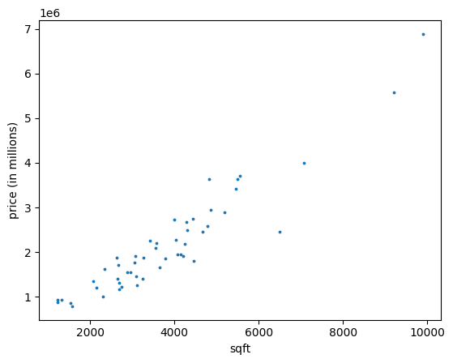

```python
data_medina = data[data['zipcode']== 98039][['sqft_living','price']]
plt.scatter(data_medina['sqft_living'], data_medina['price'], s=3)
plt.xlabel('sqft')
plt.ylabel('price (in millions)')
```

# "Fit by eye" estimate

Given the previous data set, we can attempt to 'fit' a straight line to it that describes their relationship. (This can be used to make predictions.) For now, we draw a 'fit by eye' line. In the next lesson we will discuss a method for construting a 'best-fit' line.

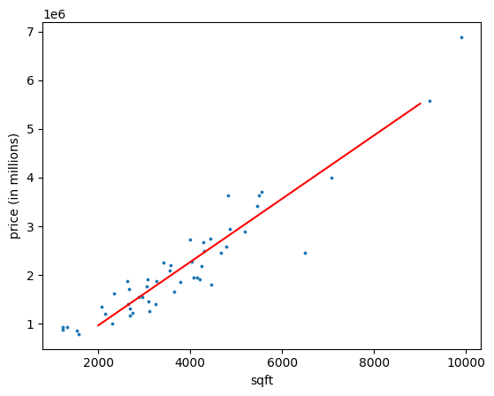

```python
X = np.linspace(2000,9000,10000)
Y = 650*X - 333000

plt.scatter(data_medina['sqft_living'], data_medina['price'], s=3)
plt.plot(X, Y, color='red')
plt.xlabel('sqft')
plt.ylabel('price (in millions)')
```

# Sample Correlation Coefficient

Given a set of paired values $(x_1,y_1), (x_2,y_2),\dots, (x_n,y_n)$, we consider a statistic called the **sample correlation coefficient** that attempts to measure the degree to which the $x$ values are correlated (related) to the $y$ values. (Do they both go up and down together, does one going up make the other go down?)

Let $\overline{x}$ and $\overline{y}$ denote the sample means for the $x$ values and the $y$ values, respectively. Likewise, let $s_x$ and $s_y$ denote the sample standard deviations for the $x$ values and the $y$ values, respectively. Then the sample correlation coefficient, $r$, is given by $$r = \frac{1}{(n-1)s_x s_y}\sum_{i=1}^n(x_i-\overline{x})(y_i-\overline{y}).$$

When $r>0$, we say that the sample pairs are **positively correlated**; and when $r<0$, we say the sample pairs are **negatively correlated**.

# Comments on $r$

$$r = \frac{1}{(n-1)s_x s_y}\sum_{i=1}^n(x_i-\overline{x})(y_i-\overline{y})$$

1. We have that $-1\leq r\leq 1$.
2. If $x_i=y_i$ for all $i$, then $r=1$. (Why?)
3. If an increase/decrease in $x$ is associated with an increase/decrease in $y$, then we expect $r>0$.
4. If an increase/decrease in $x$ is associated with an decrease/increase in $y$, then we expect $r<0$.
5. Caution: the value of $r$ alone may be deceiving!

```python
data_medina.corr()
```

|  | sqft_living | price |
| --- | --- | --- |
| sqft_living | 1.000000 | 0.940887 |
| price | 0.940887 | 1.000000 |

# Example where $r<0$

|  | x | y |
| --- | --- | --- |
| x | 1.000000 | -0.979096 |
| y | -0.979096 | 1.000000 |

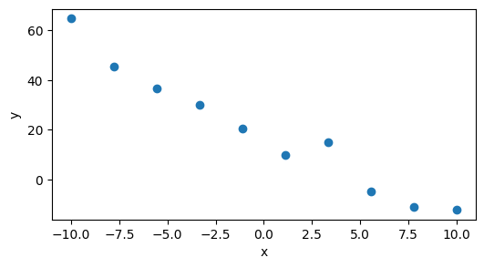

```python
X = np.linspace(-10,10,10)
Y = -4*X + 20 + 7*np.random.normal(size=len(X))
plt.scatter(X,Y)
plt.xlabel('x')
plt.ylabel('y')
d = pd.DataFrame([X,Y]).T
d.columns = ['x','y']
d.corr()
```

# Example where $r\approx 0$

|  | x | y |
| --- | --- | --- |
| x | 1.000000 | -0.101327 |
| y | -0.101327 | 1.000000 |

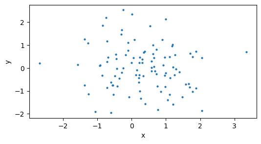

```python
X = np.random.normal(size=100)
Y = np.random.normal(size=100)
plt.scatter(X,Y, s = 4)
plt.xlabel('x')
plt.ylabel('y')
d = pd.DataFrame([X,Y]).T
d.columns = ['x','y']
d.corr()
```

# Influence of extreme values

|  | x | y |
| --- | --- | --- |
| x | 1.000000 | -0.198069 |
| y | -0.198069 | 1.000000 |

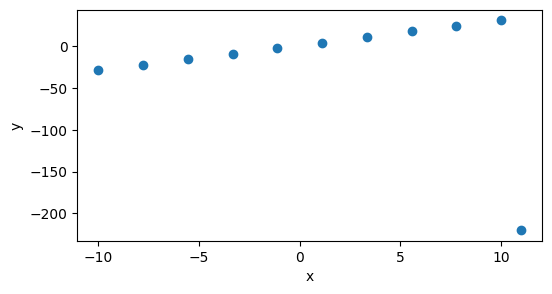

```python
x = np.linspace(-10,10,10)
y = 3*x+1
X = np.append(x,11)
Y = np.append(y,-220)
plt.scatter(X,Y)
plt.xlabel('x')
plt.ylabel('y')
d = pd.DataFrame([X,Y]).T
d.columns = ['x','y']
d.corr()
```

# Non-linear relationship

|  | x | y |
| --- | --- | --- |
| x | 1.000000e+00 | 1.489104e-16 |
| y | 1.489104e-16 | 1.000000e+00 |

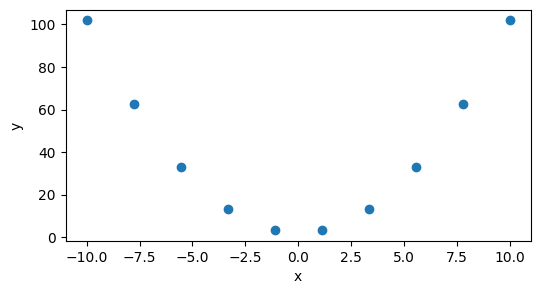

```python
X = np.linspace(-10,10,10)
Y = X**2 + 2
plt.scatter(X,Y)
plt.xlabel('x')
plt.ylabel('y')
d = pd.DataFrame([X,Y]).T
d.columns = ['x','y']
d.corr()
```